# Netflix Data Exploration: Filtering, Analysis, and Visualizations with R Studio by Andrew Romanof

Data reference: https://www.kaggle.com/datasets/dgoenrique/netflix-movies-and-tv-shows?resource=download&select=titles.csv

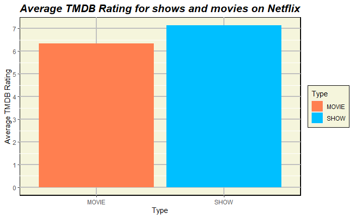

I want to see if there is a relation between the amount of seasons a TV show has and its IMDB rating. To do this, I’m goingt to break the amount of seasons to different categories: Short, Medium, Large where short means that the tv show has 1-3 seasons, medium means that the tv show has 4-8 season and that larrge means the tv show has 9+ seasons.

The below figure shows that on average, IMDB rating goes up as the amount of seasons go up (which is opposite to what I expected to find as I thought shows would get worse as more seasons get added)

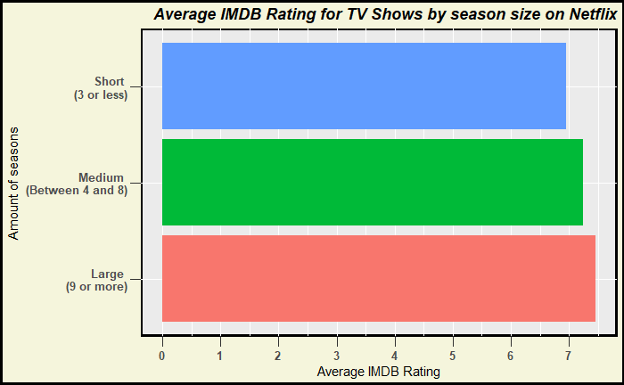

Now lets see how the IMDB score does based on countries…

The figure below shows the average IMDB rating for each country on a world map. Note: not every country is listed and some data points were missing.

We can conclude that the highest average rated movies/tv shows come from China, Tanzania (Country in Africa), Pakistan. Although, production rate in Tanzania might not be as high compared to USA, it seems that a movie from there will be more likely to be higher rated than a movie from USA showing that quality over quantity is better. It also shows that average IMDB ratings are relatively close to each other (lowest being just under 5 and the highest being just above 7) and from previous figures, the average IMDB rating overall is around 7 so the results also imply that if a country has a low average IMDB rating, then it probably hasn’t produced much.

[figure not shown]